# LARSEN_Skills_Test_3

2026-04-11

##Variables used: facsal - Faculty Salaries 1995 fstidy - Tidied version of facsal fsmod - ANOVA model for facsal, specifically using fstidy amod - ANOVA model above, but with a different command. joil - Juniper Oils tidyjoil - tidied version of joil modjoil - model for joil

##Task 1 Load and clean FacultySalaries_1995.csv file and Re-create the graph

```r
#loading libraries
library(janitor)
```

```r
library(ggplot2)
library(dplyr)
library(here)
library(tidyverse)
library(broom)


#Loading in the data
facsal<-read.csv("FacultySalaries_1995.csv")
glimpse(facsal)
```

```
## Rows: 1,161
## Columns: 17
## $ FedID               <int> 1061, 1063, 1065, 11462, 1002, 1004, 1008, 1009, 1…
## $ UnivName            <chr> "Alaska Pacific University", "Univ.Alaska-Fairbank…
## $ State               <chr> "AK", "AK", "AK", "AK", "AL", "AL", "AL", "AL", "A…
## $ Tier                <chr> "IIB", "I", "IIA", "IIA", "IIA", "IIA", "IIB", "I"…
## $ AvgFullProfSalary   <int> 454, 686, 533, 612, 442, 441, 466, 580, 498, 506, …
## $ AvgAssocProfSalary  <int> 382, 560, 494, 507, 369, 385, 394, 437, 379, 412, …
## $ AvgAssistProfSalary <int> 362, 432, 329, 414, 310, 310, 351, 374, 322, 359, …
## $ AvgProfSalaryAll    <int> 382, 508, 415, 498, 350, 388, 396, 455, 401, 411, …
## $ AvgFullProfComp     <int> 567, 914, 716, 825, 530, 542, 558, 692, 655, 607, …
## $ AvgAssocProfComp    <int> 485, 753, 663, 681, 444, 473, 476, 527, 501, 508, …
## $ AvgAssistProfComp   <int> 471, 572, 442, 557, 376, 383, 427, 451, 404, 445, …
## $ AvgProfCompAll      <int> 487, 677, 559, 670, 423, 477, 478, 546, 523, 503, …
## $ NumFullProfs        <int> 6, 74, 9, 115, 59, 57, 20, 366, 34, 67, 8, 106, 27…
## $ NumAssocProfs       <int> 11, 125, 26, 124, 77, 33, 18, 354, 25, 40, 15, 42,…
## $ NumAssistProfs      <int> 9, 118, 20, 101, 102, 35, 30, 301, 27, 66, 19, 66,…
## $ NumInstructors      <int> 4, 40, 9, 21, 24, 2, 0, 66, 3, 27, 2, 58, 4, 19, 3…
## $ NumFacultyAll       <int> 32, 404, 70, 392, 262, 127, 68, 1109, 89, 200, 44,…
```

```r
#Cleaning the data now
facsal <- read.csv(here("FacultySalaries_1995.csv")) |>
  clean_names()
#I'll be so real with you, I have no idea what this next line does, ChatGPT recommended to me.
#I couldn't tell a difference in before/after it. I've commented it since Idk what it does.
#facsal <- facsal |>
  #mutate(univ_name = stringr::str_squish(univ_name))
unique(facsal$state)
```

```
##  [1] "AK" "AL" "AR" "AZ" "CA" "CO" "CT" "DC" "DE" "FL" "GA" "HI" "IA" "ID" "IL"
## [16] "IN" "KS" "KY" "LA" "MA" "MD" "ME" "MI" "MN" "MO" "MS" "MT" "NC" "ND" "NE"
## [31] "NH" "NJ" "NM" "NV" "NY" "OH" "OK" "OR" "PA" "RI" "SC" "SD" "TN" "TX" "UT"
## [46] "VA" "VT" "WA" "WI" "WV" "WW" "WY"
```

```r
#uh oh. There's only 50 states, why am I getting back 52 codes?
#It's including DC, that's okay.
#But what's WW. We can check using other data, from universitys
facsal |>
  filter(state == "WW")
```

```
##   fed_id        univ_name state tier avg_full_prof_salary avg_assoc_prof_salary
## 1   3822 Shepherd College    WW VIIB                  415                   348
##   avg_assist_prof_salary avg_prof_salary_all avg_full_prof_comp
## 1                    312                 342                508
##   avg_assoc_prof_comp avg_assist_prof_comp avg_prof_comp_all num_full_profs
## 1                 421                  383               418             27
##   num_assoc_profs num_assist_profs num_instructors num_faculty_all
## 1              31               33              14             115
```

```r
#So, it's Shepard College. I looked that up. Well, it looks like it's a University now, but still.
facsal <- facsal |>
  mutate(state = dplyr::recode(state, "WW" = "WV"))
unique(facsal$state)
```

```
##  [1] "AK" "AL" "AR" "AZ" "CA" "CO" "CT" "DC" "DE" "FL" "GA" "HI" "IA" "ID" "IL"
## [16] "IN" "KS" "KY" "LA" "MA" "MD" "ME" "MI" "MN" "MO" "MS" "MT" "NC" "ND" "NE"
## [31] "NH" "NJ" "NM" "NV" "NY" "OH" "OK" "OR" "PA" "RI" "SC" "SD" "TN" "TX" "UT"
## [46] "VA" "VT" "WA" "WI" "WV" "WY"
```

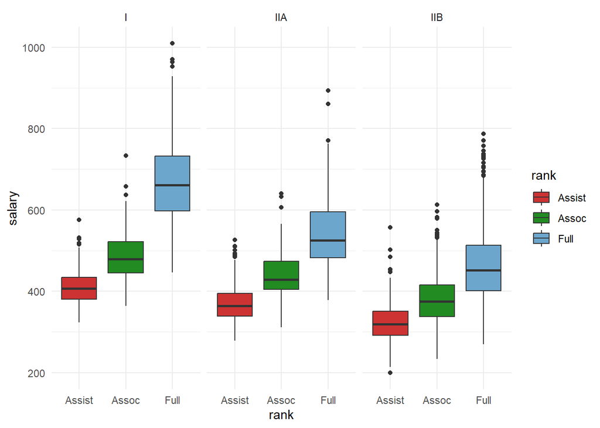

```r
#Excellent, that's working now.
#Other fixing. Again on Shepard's College, there was a weird error I noticed after tyring to graph and having t come back here again.
facsal <- facsal |>
  mutate(tier = recode(tier, "VIIB" = "IIB"))
facsal <- facsal |>
  mutate(tier = factor(tier, levels = c("I", "IIA", "IIB")))
facsal <- facsal |>
  mutate(state = factor(state))
#Now making it tidy.
fstidy <- facsal |>
  pivot_longer(
    cols = c(avg_assist_prof_salary,
             avg_assoc_prof_salary,
             avg_full_prof_salary),
    names_to = "rank",
    values_to = "salary"
  )
#And even tidier
fstidy<- fstidy |>
  mutate(
    rank = recode(rank,
      "avg_assist_prof_salary" = "Assist",
      "avg_assoc_prof_salary"  = "Assoc",
      "avg_full_prof_salary"   = "Full"
    ),
    rank = factor(rank, levels = c("Assist", "Assoc", "Full"))
  )
fstidy <- fstidy |>
  filter(is.finite(salary))

#Making the plot
ggplot(fstidy, aes(x = rank, y = salary, fill = rank)) +
  geom_boxplot() +
  facet_wrap(~ tier, nrow = 1) +
  scale_fill_manual(values = c(
    "Assist" = "brown3",
    "Assoc"  = "forestgreen",
    "Full"   = "skyblue3"
  )) +
  theme_minimal()
```

##Task 2 Build an ANOVA model and display the summary output in your report.

```r
#This is how I did it in my stats as well as the other homework assignments. I'll stick to this way here.
fsmod <- lm(salary ~ state + tier + rank, data = fstidy)
#Viewing the ANOVA table.
summary(fsmod)
```

```
##
## Call:
## lm(formula = salary ~ state + tier + rank, data = fstidy)
##
## Residuals:
##     Min      1Q  Median      3Q     Max
## -206.44  -36.27   -2.13   31.88  329.51
##
## Coefficients:
##             Estimate Std. Error t value Pr(>|t|)
## (Intercept)  474.855     17.607  26.970  < 2e-16 ***
## stateAL      -70.505     18.991  -3.713 0.000209 ***
## stateAR      -55.255     19.606  -2.818 0.004858 **
## stateAZ      -84.747     24.663  -3.436 0.000597 ***
## stateCA       22.566     18.050   1.250 0.211313
## stateCO      -40.962     19.639  -2.086 0.037073 *
## stateCT       37.744     19.506   1.935 0.053084 .
## stateDC       -9.245     21.061  -0.439 0.660709
## stateDE      -17.946     25.168  -0.713 0.475859
## stateFL      -39.752     19.146  -2.076 0.037945 *
## stateGA      -38.425     18.990  -2.023 0.043111 *
## stateHI       35.448     27.539   1.287 0.198112
## stateIA      -36.261     18.787  -1.930 0.053676 .
## stateID      -87.704     23.348  -3.756 0.000175 ***
## stateIL      -31.319     18.139  -1.727 0.084328 .
## stateIN      -44.317     18.294  -2.422 0.015469 *
## stateKS     -103.214     19.286  -5.352 9.31e-08 ***
## stateKY      -68.868     18.981  -3.628 0.000290 ***
## stateLA      -65.741     19.091  -3.444 0.000581 ***
## stateMA       33.905     18.221   1.861 0.062868 .
## stateMD       -9.557     18.968  -0.504 0.614400
## stateME      -24.478     19.874  -1.232 0.218164
## stateMI      -21.462     18.538  -1.158 0.247065
## stateMN      -18.857     18.763  -1.005 0.314967
## stateMO      -61.571     18.478  -3.332 0.000871 ***
## stateMS     -101.579     20.037  -5.069 4.21e-07 ***
## stateMT     -119.917     21.312  -5.627 1.99e-08 ***
## stateNC      -46.825     18.272  -2.563 0.010431 *
## stateND      -84.899     22.733  -3.735 0.000191 ***
## stateNE      -56.411     19.474  -2.897 0.003795 **
```

[output cut: 16 more lines]

```
## stateVT      -47.415     20.946  -2.264 0.023660 *
## stateWA      -39.476     19.635  -2.011 0.044455 *
## stateWI      -37.419     18.668  -2.004 0.045109 *
## stateWV      -78.585     19.504  -4.029 5.72e-05 ***
## stateWY     -112.046     38.975  -2.875 0.004068 **
## tierIIA      -79.328      3.258 -24.352  < 2e-16 ***
## tierIIB     -131.860      3.096 -42.593  < 2e-16 ***
## rankAssoc     63.840      2.535  25.181  < 2e-16 ***
## rankFull     170.733      2.554  66.846  < 2e-16 ***
## ---
## Signif. codes:  0 '***' 0.001 '**' 0.01 '*' 0.05 '.' 0.1 ' ' 1
##
## Residual standard error: 60.28 on 3300 degrees of freedom
## Multiple R-squared:  0.7095, Adjusted R-squared:  0.7047
## F-statistic: 149.2 on 54 and 3300 DF,  p-value: < 2.2e-16
```

```r
#yeah, okay, that's unreadable to me.
amod<-aov(salary ~ state + tier + rank, data=fstidy)
summary(amod)
```

```
##               Df   Sum Sq Mean Sq F value Pr(>F)
## state         50  5682339  113647   31.28 <2e-16 ***
## tier           2  7071600 3535800  973.09 <2e-16 ***
## rank           2 16529796 8264898 2274.58 <2e-16 ***
## Residuals   3300 11990864    3634
## ---
## Signif. codes:  0 '***' 0.001 '**' 0.01 '*' 0.05 '.' 0.1 ' ' 1
```

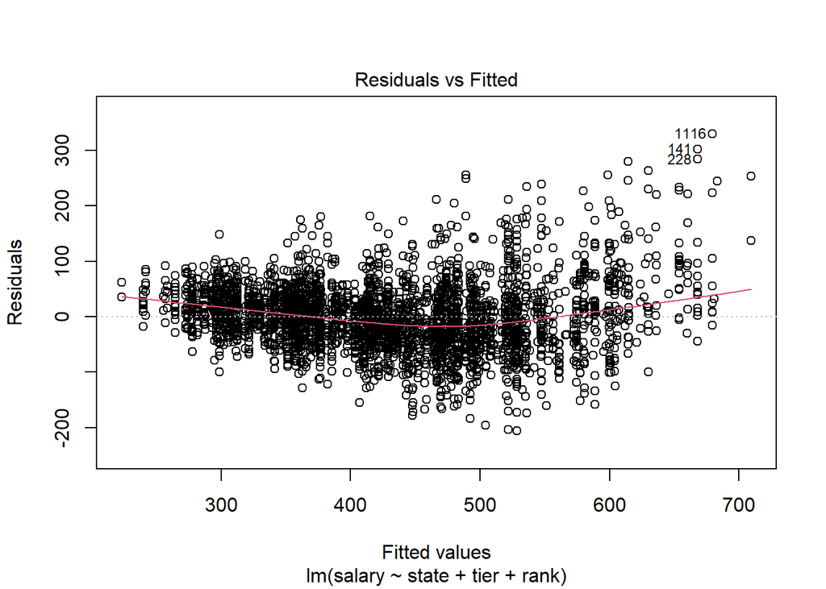

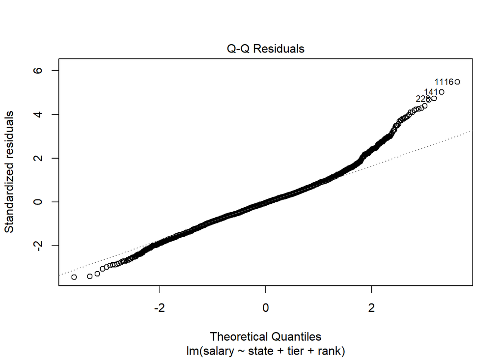

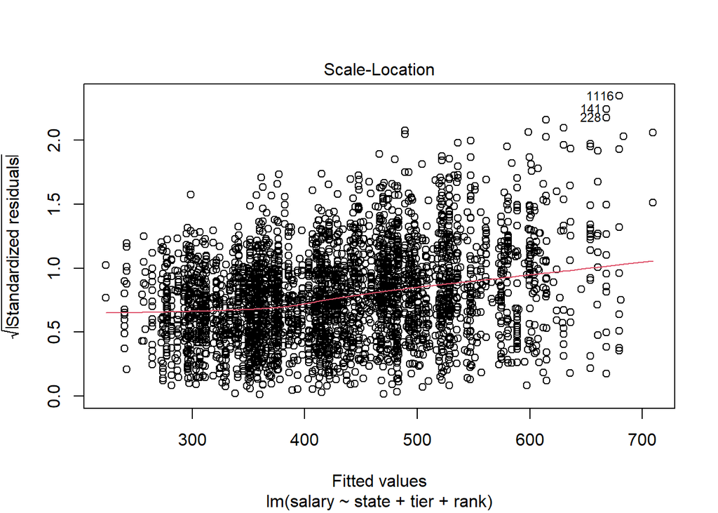

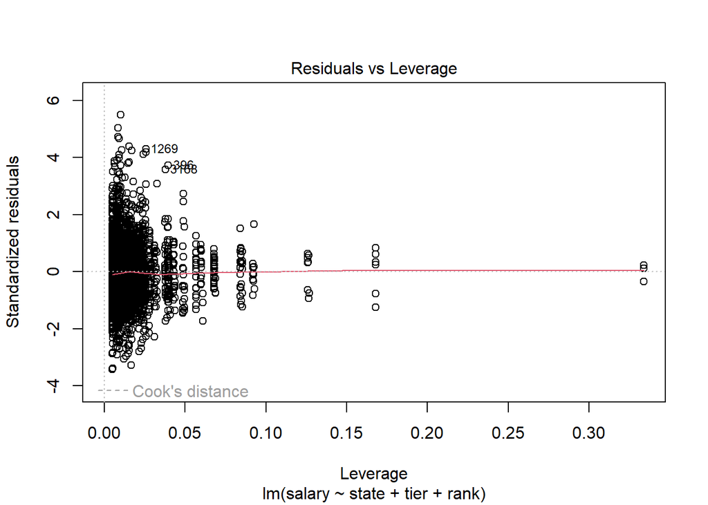

```r
#Much better. Let's use that one.
#Let's plot it for sanity sake now.
plot(fsmod)
```